# NGupta_HW4

Nikhil Gupta

September 19, 2018

```r
# Load all required Libraries
library(rvest)
library(tidyr)
library(dplyr)
```

```r
library(ggplot2)
```

# 1. Harry Potter Cast (50%)

### 1a

In the IMDB, there are listings of full cast members for movies. Navigate to http://www.imdb.com/title/tt1201607/fullcredits?ref_=tt_ql_1. Feel free to View Source to get a good idea of what the page looks like in code.

### 1b

Scrape the page with any R package that makes things easy for you. Of particular interest is the table of the Cast in order of crediting. Please scrape this table (you might have to fish it out of several of the tables from the page) and make it a data.frame() of the Cast in your R environment

```r
# Adapted from https://www.analyticsvidhya.com/blog/2017/03/beginners-guide-on-web-scraping-in-r-using-rvest-with-hands-on-knowledge/

url <- "http://www.imdb.com/title/tt1201607/fullcredits?ref_=tt_ql_1"
webpage <- read_html(url)
cast_html <- html_nodes(webpage,'.cast_list td')

#Converting the names to text
cast <- html_text(cast_html)

#EDA
str(cast)
```

```
##  chr [1:618] "" "\n          " "\n Ralph Fiennes\n          " ...
```

```r
# This is a string vector. This will be cleaned up and converted to a dataframe in 1c
```

### 1c

Clean up the table

- It should not have blank observations or rows, a row that should be column names, or just “…”
- It should have intuitive column names (ideally 2 to start - Actor and Character)
- In the film, Mr. Warwick plays two characters, which makes his row look a little weird. Please replace his character column with just “Griphook / Professor Filius Flitwick” to make it look better.
- One row might result in “Rest of cast listed alphabetically” - remove this observation.

```r
# (1) change all wierd entries to "". This will be cleaned up later
cast <- gsub("\n          ","",cast)
cast <- gsub("    ...","",cast)
cast <- gsub("\n ","",cast)

# (2) remove leading and trailing white spaces
cast <- gsub("^ +","",cast) # remove leading white spaces
cast <- gsub(" +$","",cast) # remove trailing white spaces

# (3) remove all empty entries and header in middle of the table
cast <- cast[cast != ""] # remove empty entries
cast <- cast[cast != "Rest of cast listed alphabetically:"] # remove header

# check the results
head(cast)
```

```
## [1] "Ralph Fiennes"              "Lord Voldemort"
## [3] "Michael Gambon"             "Professor Albus Dumbledore"
## [5] "Alan Rickman"               "Professor Severus Snape"
```

```r
str(cast)
```

```
##  chr [1:308] "Ralph Fiennes" "Lord Voldemort" "Michael Gambon" ...
```

```r
# separate vector into Actor and Character
odd <- seq(1,length(cast),2)
even <- seq(2,length(cast),2)
Actor <- cast[odd]
Character <- cast[even]
data <- data.frame(Actor,Character, stringsAsFactors = FALSE)

# clean up entry
data[Actor == 'Warwick Davis','Character'] <- 'Griphook / Professor Filius Flitwick'

# Check the results
str(data)
```

```
## 'data.frame':    154 obs. of  2 variables:
##  $ Actor    : chr  "Ralph Fiennes" "Michael Gambon" "Alan Rickman" "Daniel Radcliffe" ...
##  $ Character: chr  "Lord Voldemort" "Professor Albus Dumbledore" "Professor Severus Snape" "Harry Potter" ...
```

```r
head(data,10)
```

```
##               Actor                            Character
## 1     Ralph Fiennes                       Lord Voldemort
## 2    Michael Gambon           Professor Albus Dumbledore
## 3      Alan Rickman              Professor Severus Snape
## 4  Daniel Radcliffe                         Harry Potter
## 5      Rupert Grint                          Ron Weasley
## 6       Emma Watson                     Hermione Granger
## 7      Evanna Lynch                        Luna Lovegood
## 8  Domhnall Gleeson                         Bill Weasley
## 9    Clémence Poésy                       Fleur Delacour
## 10    Warwick Davis Griphook / Professor Filius Flitwick
```

### 1d

Split the Actor’s name into two columns: FirstName and Surname. Keep in mind that some actors/actresses have middle names as well. Please make sure that the middle names are in the FirstName column, in addition to the first name (example: given the Actor Frank Jeffrey Stevenson, the FirstName column would say “Frank Jeffrey”.)

```r
# regular expression below splits on the final space only
# adapted from https://stackoverflow.com/questions/19959697/split-string-by-final-space-in-r
cast <- data %>% separate(col = Actor, into = c("FirstName", "Surname"), sep = " (?=[^ ]+$)")
# check that the split happened correctly
data[c(12,36,78,81,86, 95, 107, 111, 115, 116),c('Actor')]
```

```
##  [1] "Helena Bonham Carter"          "Sian Grace Phillips"
##  [3] "Peter G. Reed"                 "Bob Yves Van Hellenberg Hubar"
##  [5] "Daphne de Beistegui"           "Michael Henbury Ballan"
##  [7] "Gioacchino Jim Cuffaro"        "Sarah-Jane De Crespigny"
##  [9] "Grace Meurisse Francis"        "Sean Francis George"
```

```r
cast[c(12,36,78,81,86, 95, 107, 111, 115, 116),c('FirstName','Surname')]
```

```
##                   FirstName   Surname
## 12            Helena Bonham    Carter
## 36               Sian Grace  Phillips
## 78                 Peter G.      Reed
## 81  Bob Yves Van Hellenberg     Hubar
## 86                Daphne de Beistegui
## 95          Michael Henbury    Ballan
## 107          Gioacchino Jim   Cuffaro
## 111           Sarah-Jane De Crespigny
## 115          Grace Meurisse   Francis
## 116            Sean Francis    George
```

### 1e

Present the first 10 rows of the data.frame() - It should have only FirstName, Surname, and Character columns.

```r
head(cast,10) # Print the 1st 10 rows
```

```
##    FirstName   Surname                            Character
## 1      Ralph   Fiennes                       Lord Voldemort
## 2    Michael    Gambon           Professor Albus Dumbledore
## 3       Alan   Rickman              Professor Severus Snape
## 4     Daniel Radcliffe                         Harry Potter
## 5     Rupert     Grint                          Ron Weasley
## 6       Emma    Watson                     Hermione Granger
## 7     Evanna     Lynch                        Luna Lovegood
## 8   Domhnall   Gleeson                         Bill Weasley
## 9   Clémence     Poésy                       Fleur Delacour
## 10   Warwick     Davis Griphook / Professor Filius Flitwick
```

# 2. SportsBall (50%)

### 2a

On the ESPN website, there are statistics of each NBA player. Navigate to the San Antonio Spurs current statistics (likely http://www.espn.com/nba/team/stats/_/name/sa/san-antonio-spurs). You are interested in the Shooting Statistics table.

### 2b

Scrape the page with any R package that makes things easy for you. There are a few tables on the page, so make sure you are targeting specifically the Shooting Statistics table.

```r
# Adapted from https://www.r-bloggers.com/using-rvest-to-scrape-an-html-table/
url <- "http://www.espn.com/nba/team/stats/_/name/sa/san-antonio-spurs"
webpage <- read_html(url)

shooting.stats <- webpage %>%
  html_nodes(xpath='//*[@id="my-players-table"]/div[4]/div[3]/table') %>%
  html_table()

shooting.stats <- shooting.stats[[1]]

# Exploratory Analysis
str(shooting.stats)
```

```
## 'data.frame':    17 obs. of  15 variables:
##  $ X1 : chr  "SHOOTING STATISTICS" "PLAYER" "LaMarcus Aldridge, PF" "Patty Mills, PG" ...
##  $ X2 : chr  "SHOOTING STATISTICS" "FGM" "7.4" "5.0" ...
##  $ X3 : chr  "SHOOTING STATISTICS" "FGA" "16.0" "11.4" ...
##  $ X4 : chr  "SHOOTING STATISTICS" "FG%" ".463" ".439" ...
##  $ X5 : chr  "SHOOTING STATISTICS" "3PM" "0.6" "2.6" ...
##  $ X6 : chr  "SHOOTING STATISTICS" "3PA" "1.0" "7.0" ...
##  $ X7 : chr  "SHOOTING STATISTICS" "3P%" ".600" ".371" ...
##  $ X8 : chr  "SHOOTING STATISTICS" "FTM" "8.2" "0.8" ...
##  $ X9 : chr  "SHOOTING STATISTICS" "FTA" "8.4" "1.0" ...
##  $ X10: chr  "SHOOTING STATISTICS" "FT%" "0.98" "0.80" ...
##  $ X11: chr  "SHOOTING STATISTICS" "2PM" "6.8" "2.4" ...
##  $ X12: chr  "SHOOTING STATISTICS" "2PA" "15.0" "4.4" ...
##  $ X13: chr  "SHOOTING STATISTICS" "2P%" ".453" ".545" ...
##  $ X14: chr  "SHOOTING STATISTICS" "PPS" "1.475" "1.175" ...
##  $ X15: chr  "SHOOTING STATISTICS" "AFG%" "0.48" "0.55" ...
```

### 2c

Clean up the table (You might get some warnings if you are working with tibbles)

- You will want to create an R data.frame() with one observation for each player. Make sure that you do not accidentally include blank rows, a row of column names, or the Totals row in the table as observations.
- The column PLAYER has two variables of interest in it: the player’s name and their position, denoted by 1-2 letters after their name. Split the cells into two columns, one with Name and the other Position.
- Check the data type of all columns. Convert relevant columns to numeric. Check the data type of all columns again to confirm that they have changed!

```r
shooting.stats <-  shooting.stats[-1,] # remove 1st row which contains the table name in all columns

# The new 1st row now contains the actual column names
# Set the column names appropriately
column.names <- shooting.stats[1,]
shooting.stats <-  shooting.stats[-1,]
colnames(shooting.stats) <- column.names

# Last row contains total. Remove this
shooting.stats <- filter(shooting.stats, PLAYER != 'Totals')
# Split PLAYER into Name and Position
shooting.stats <- shooting.stats %>% separate(col = PLAYER, into = c("Name", "Position"), sep = ",")

# Check and convert data types to numeric as needed
str(shooting.stats)
```

```
## 'data.frame':    14 obs. of  16 variables:
##  $ Name    : chr  "LaMarcus Aldridge" "Patty Mills" "Rudy Gay" "Manu Ginobili" ...
##  $ Position: chr  " PF" " PG" " SF" " G" ...
##  $ FGM     : chr  "7.4" "5.0" "5.2" "3.0" ...
##  $ FGA     : chr  "16.0" "11.4" "13.0" "7.4" ...
##  $ FG%     : chr  ".463" ".439" ".400" ".405" ...
##  $ 3PM     : chr  "0.6" "2.6" "0.8" "1.2" ...
##  $ 3PA     : chr  "1.0" "7.0" "3.6" "3.6" ...
##  $ 3P%     : chr  ".600" ".371" ".222" ".333" ...
##  $ FTM     : chr  "8.2" "0.8" "1.0" "1.8" ...
##  $ FTA     : chr  "8.4" "1.0" "1.8" "2.2" ...
##  $ FT%     : chr  "0.98" "0.80" "0.56" "0.82" ...
##  $ 2PM     : chr  "6.8" "2.4" "4.4" "1.8" ...
##  $ 2PA     : chr  "15.0" "4.4" "9.4" "3.8" ...
##  $ 2P%     : chr  ".453" ".545" ".468" ".474" ...
##  $ PPS     : chr  "1.475" "1.175" ".938" "1.216" ...
##  $ AFG%    : chr  "0.48" "0.55" "0.43" "0.49" ...
```

```r
shooting.stats[,-c(1,2)] <- as.data.frame(sapply(shooting.stats[,-c(1,2)], as.numeric))
str(shooting.stats)
```

```
## 'data.frame':    14 obs. of  16 variables:
##  $ Name    : chr  "LaMarcus Aldridge" "Patty Mills" "Rudy Gay" "Manu Ginobili" ...
##  $ Position: chr  " PF" " PG" " SF" " G" ...
##  $ FGM     : num  7.4 5 5.2 3 2.8 2.8 2 2.4 1.3 1.6 ...
##  $ FGA     : num  16 11.4 13 7.4 6.2 7.4 4 4 4.3 6 ...
##  $ FG%     : num  0.463 0.439 0.4 0.405 0.452 0.378 0.5 0.6 0.294 0.267 ...
##  $ 3PM     : num  0.6 2.6 0.8 1.2 0.8 0 0.2 0 0.5 1 ...
##  $ 3PA     : num  1 7 3.6 3.6 1.2 1 0.6 0.8 2.3 4 ...
##  $ 3P%     : num  0.6 0.371 0.222 0.333 0.667 0 0.333 0 0.222 0.25 ...
##  $ FTM     : num  8.2 0.8 1 1.8 1.4 1 1.8 0.6 1.3 0 ...
##  $ FTA     : num  8.4 1 1.8 2.2 1.8 1.4 2 0.8 1.8 0 ...
##  $ FT%     : num  0.98 0.8 0.56 0.82 0.78 0.71 0.9 0.75 0.71 0 ...
##  $ 2PM     : num  6.8 2.4 4.4 1.8 2 2.8 1.8 2.4 0.8 0.6 ...
##  $ 2PA     : num  15 4.4 9.4 3.8 5 6.4 3.4 3.2 2 2 ...
##  $ 2P%     : num  0.453 0.545 0.468 0.474 0.4 0.438 0.529 0.75 0.375 0.3 ...
##  $ PPS     : num  1.475 1.175 0.938 1.216 1.258 ...
##  $ AFG%    : num  0.48 0.55 0.43 0.49 0.52 0.38 0.53 0.6 0.35 0.35 ...
```

### 2d

Create a colorful bar chart that shows the Field Goals Percentage Per Game for each person. It will be graded on the following criteria.

- Informative Title, centered
- Relevant x and y axis labels (not simply variables names!)
- Human-readable axes with no overlap (you might have to flip x and y to fix that). Note: You do not have to convert the decimal to a percentage.
- Color the columns by the team member’s position (so, all PF’s should have the same color, etc.)

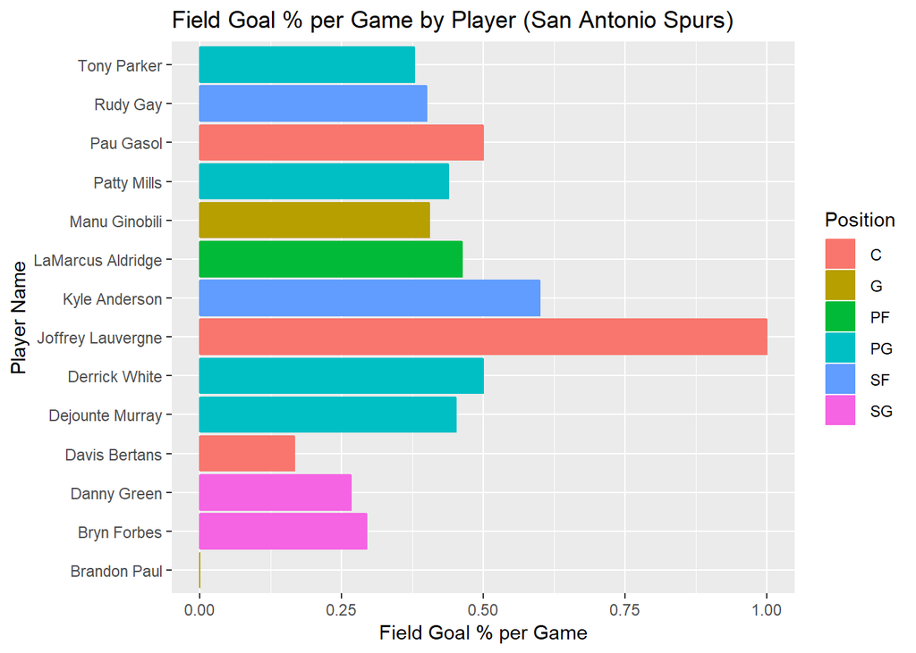

```r
pl <- ggplot(shooting.stats, aes(x=Name,y=`FG%`,color=Position, fill=Position)) + geom_bar(stat="identity") +
  ggtitle("Field Goal % per Game by Player (San Antonio Spurs)") + xlab("Player Name") + ylab("Field Goal % per Game") +
  coord_flip()
print (pl)
```